# Statistical Computing Quiz 2022

Zeynep Filiz EREN

4/23/2022

## **Questions**

### **Question 1.**

One way to measure a person’s fitness is to measure their body fat percentage. Average body fat percentages vary by age, but according to some guidelines, the normal range for men is 15-20% body fat, and the normal range for women is 20-25% body fat.  
Our sample data is from a group of men and women who did workouts at a gym three times a week for a year. Then, their trainer measured the body fat and wonders whether the body fat is the same for men and women. The table below shows the data.

| Men | 1 | 8 | 14 | 13 | 20 | 24 | 16 | 7 | 6 | 19 |
| --- | --- | --- | --- | --- | --- | --- | --- | --- | --- | --- |
| Women | 5 | 7 | 22 | 21 | 23 | 28 | 16 | 6 | 12 | 23 |

```r
  men <- c(1,8,14,13,20,24,16,7,6,19)
  women <- c(5,7,22,21,23,28,16,6,12,23)
```

**a.** Build histograms and boxplots for each group. Comment about the distribution and the outliers.

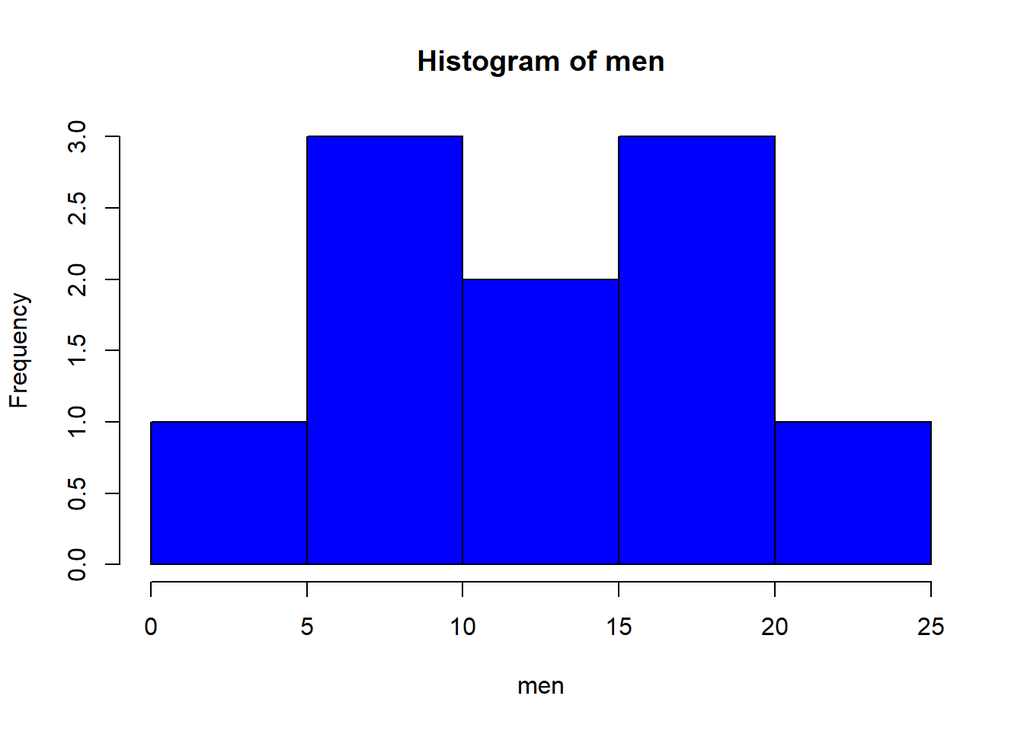

```r
  hist(men,col="blue",breaks = 8)
```

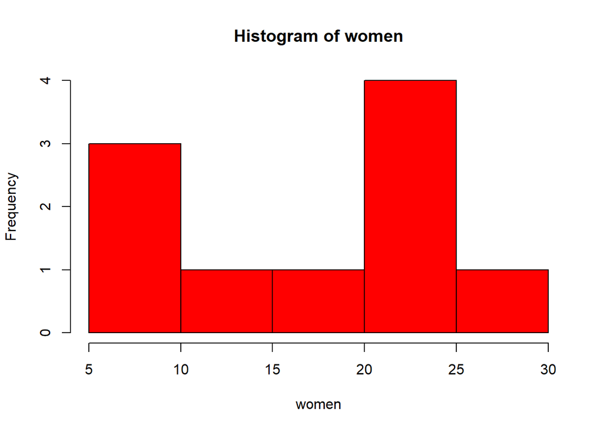

```r
  hist(women,col = "red",breaks = 8)
```

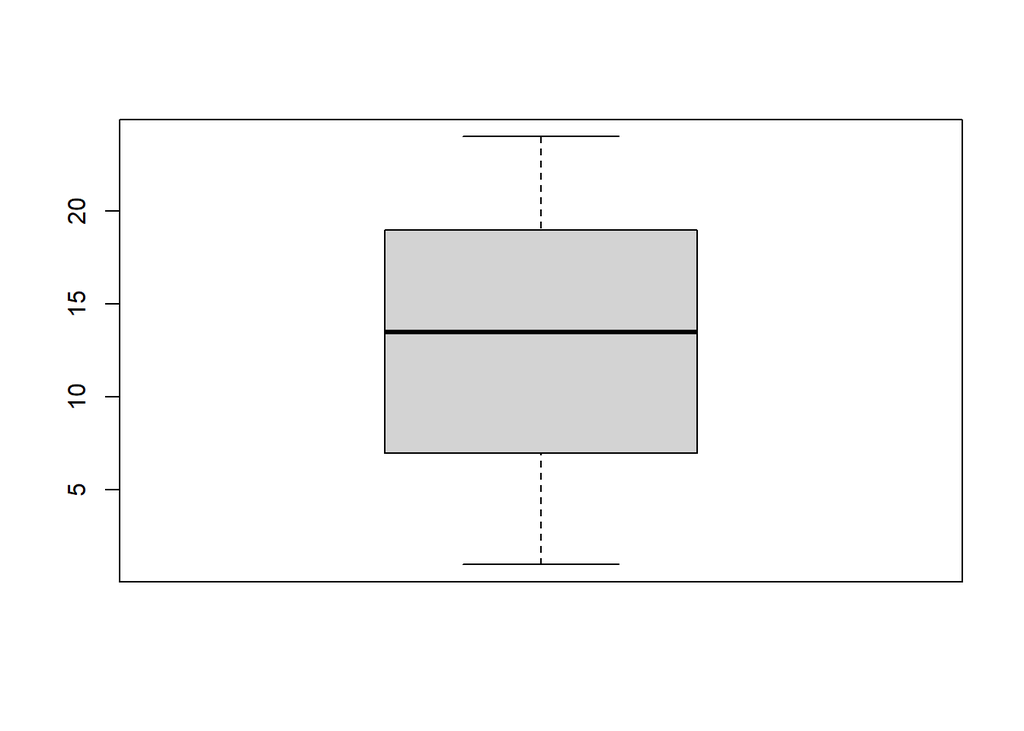

```r
  boxplot(men)
```

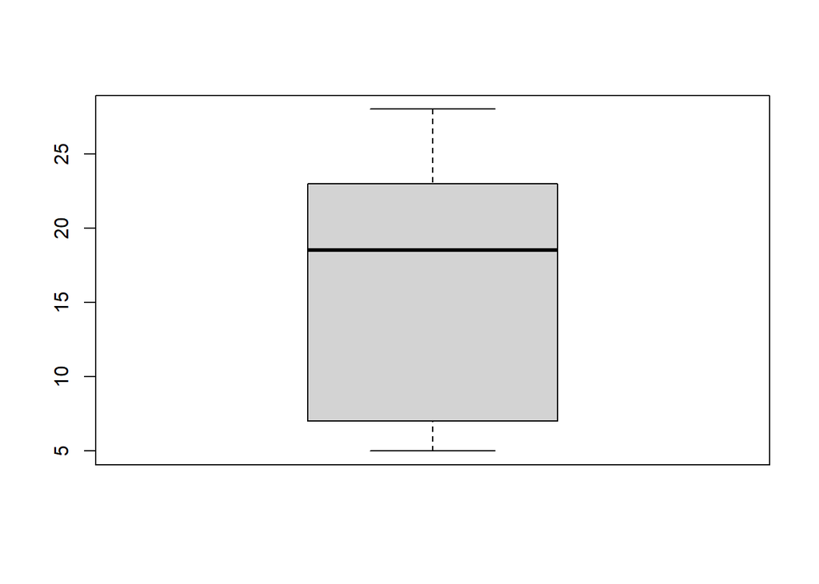

```r
  boxplot(women)
```

**b.** Write down a hypothesis to test if gender affects the amount of body fat.

µ0 = mean(men)

µ1 = mean(women)

H0: µ0 = µ1

H1: µ0 != µ1

**c.** Decide whether this is an independent or dependent two sample test.

These datasets are not dependent, therefore we will do independent two sample t-test.

**d.** Check normality assumption/ assumptions needed.

```r
  shapiro.test(men)
```

```
##
##  Shapiro-Wilk normality test
##
## data:  men
## W = 0.97481, p-value = 0.9315
```

```r
  shapiro.test(women)
```

```
##
##  Shapiro-Wilk normality test
##
## data:  women
## W = 0.90167, p-value = 0.2285
```

H0: Data is Normally Distributed

H1: Data is not Normally Distributed alpha=0.05

If p <= 0.05: then the null hypothesis can be rejected (meaning the variable is not normally distributed).

If p > 0.05: then the null hypothesis can not be rejected (meaning the variable might be normally distributed or not).

p>0.05, two samples are normally distributed.

**e.** Test your hypothesis. (α=0.05)

```r
  t.test(men,women,alternative = "two.sided",mu=0,paired = FALSE,var.equal = TRUE)
```

```
##
##  Two Sample t-test
##
## data:  men and women
## t = -1.0059, df = 18, p-value = 0.3278
## alternative hypothesis: true difference in means is not equal to 0
## 95 percent confidence interval:
##  -10.810417   3.810417
## sample estimates:
## mean of x mean of y
##      12.8      16.3
```

**f.** Comment:

We can not reject H0, which means the means of the two datasets can be equal but they might be different as well.

**g.** Write down a hypothesis to test if being a women means “the person is more likely to have more body fat”.

µ0 = men

µ1 = women

H0: µ0 >= µ1

H1: µ0 < µ1

**h.** Test your hypothesis. (α=0.05)

```r
  t.test(men,women,alternative = "greater",mu=0,paired = FALSE,var.equal = TRUE)
```

```
##
##  Two Sample t-test
##
## data:  men and women
## t = -1.0059, df = 18, p-value = 0.8361
## alternative hypothesis: true difference in means is greater than 0
## 95 percent confidence interval:
##  -9.533888       Inf
## sample estimates:
## mean of x mean of y
##      12.8      16.3
```

**i.** Comment:

**j.** Find the confidence intervals of mean body fat for men and women separately and compare them. (α=0.05)

```r
  t.score <-  qt(p=0.05, df=length(men)-1,lower.tail=F)

  men.mean <- mean(men)
  men.sd <- sd(men)
  men.se <- men.sd/sqrt(length(men))
  error <- t.score * men.se
  lower.bound <- men.mean  - error
  upper.bound <- men.mean  + error
  print(c(lower.bound,upper.bound))
```

```
## [1]  8.61272 16.98728
```

```r
  t.score <-  qt(p=0.05, df=length(women)-1,lower.tail=F)

  women.mean <- mean(women)
  women.sd <- sd(women)
  women.se <- women.sd/sqrt(length(women))
  error <- t.score * women.se
  lower.bound <- women.mean  - error
  upper.bound <- women.mean  + error
  print(c(lower.bound,upper.bound))
```

```
## [1] 11.4883 21.1117
```

### **Question 2.**

**The same data, but totally different scenario: Lets say the below table corresponds to the “%body fat of 10 people”, which are measured at the time they started doing sports for 3 times a week; and after 3 months.**

| After 3 months | 1 | 8 | 14 | 13 | 20 | 24 | 16 | 7 | 6 | 19 |
| --- | --- | --- | --- | --- | --- | --- | --- | --- | --- | --- |
| Start day | 5 | 7 | 22 | 21 | 23 | 28 | 16 | 6 | 12 | 23 |

```r
  start <- c(5,7,22,21,23,28,16,6,12,23)
  after <- c(1,8,14,13,20,24,16,7,6,19)
```

**a.** Write down a hypothesis to test if doing sports decreases the amount of body fat.

µ0 = start

µ1 = after

H0: µ0 <= µ1

H1: µ0 > µ1

**b.** Decide whether this is an independent or dependent two sample test.

Since people are the same, samples are dependent. Therefore we will need dependent two sample t-test.

**c.** Check normality assumption/assumptions.

```r
  shapiro.test(start)
```

```
##
##  Shapiro-Wilk normality test
##
## data:  start
## W = 0.90167, p-value = 0.2285
```

```r
  shapiro.test(after)
```

```
##
##  Shapiro-Wilk normality test
##
## data:  after
## W = 0.97481, p-value = 0.9315
```

H0: Data is Normally Distributed H1: Data is not Normally Distributed alpha=0.05

**d.** Test your hypothesis. (α=0.05)

```r
  t.test(start,after, mu =0 ,paired = TRUE, alternative = "less",conf.level = 0.95)
```

```
##
##  Paired t-test
##
## data:  start and after
## t = 3.3121, df = 9, p-value = 0.9955
## alternative hypothesis: true difference in means is less than 0
## 95 percent confidence interval:
##      -Inf 5.437095
## sample estimates:
## mean of the differences
##                     3.5
```

**e.** Comment:

### **Question 3.**

**Another scenario: Lets say the below table corresponds to the “muscle gain of 30 people who started doing sports 6 months ago”: 1st group did sports once a week, 2nd group did sports three times a week, 3rd group did sports five times a week.**

| Group 1 | 1 | 3 | 6 | 5 | 7 | 2 | 1 | 2 | 3 | 5 |
| --- | --- | --- | --- | --- | --- | --- | --- | --- | --- | --- |
| Group 2 | 9 | 7 | 7 | 4 | 3 | 6 | 5 | 4 | 6 | 7 |
| Group 3 | 6 | 8 | 7 | 7 | 9 | 5 | 7 | 8 | 6 | 7 |

```r
  group1 <- c(1,3,6,5,7,2,1,2,3,5)
  group2 <- c(9,7,7,4,3,6,5,4,6,7)
  group3 <- c(6,8,7,7,9,5,7,8,6,7)
```

**a.** Write down a hypothesis to test if these groups have equal means or not. (α=0.05)

H0: µ0 = µ1 = µ2

H1: At least one of the means is different.

```r
groups <- c(group1,group2,group3)
frequent  <- as.factor(c(rep("once",10),rep("three",10),rep("five",10)))
data <- data.frame(groups,frequent)

bartlett.test(groups~frequent,data = data)
```

```
##
##  Bartlett test of homogeneity of variances
##
## data:  groups by frequent
## Bartlett's K-squared = 3.036, df = 2, p-value = 0.2191
```

```r
model <- aov(groups~frequent,data = data)
summary(model)
```

```
##             Df Sum Sq Mean Sq F value   Pr(>F)
## frequent     2  63.27   31.63    10.4 0.000447 ***
## Residuals   27  82.10    3.04
## ---
## Signif. codes:  0 '***' 0.001 '**' 0.01 '*' 0.05 '.' 0.1 ' ' 1
```

**b.** Comment:

**c.** Implement TukeyHSD test and compare the groups. (α=0.05)

```r
  TukeyHSD(model)
```

```
##   Tukey multiple comparisons of means
##     95% family-wise confidence level
##
## Fit: aov(formula = groups ~ frequent, data = data)
##
## $frequent
##            diff        lwr        upr     p adj
## once-five  -3.5 -5.4335455 -1.5664545 0.0003444
## three-five -1.2 -3.1335455  0.7335455 0.2892452
## three-once  2.3  0.3664545  4.2335455 0.0173050
```

**d.** Comment:

Since p-values of the comparisons “once-five” and “three-once” are less then 0.05, we can say that “once” is especially different from other two.